# Bootstratp

Marcin Mazurek

2017-11-30

# Repróbkowanie

Metoda estymacji błędu predykcji.

## Zbiór testowy wyodrębniony z próby prostej:

1. Klasyczne podejśćie: Jeżeli dysponujemy wystarczająco liczną próbą, wyodrębniamy z niej ciąg walidujący (testowy).

```r
library(ISLR)
head(Auto)
```

```
##   mpg cylinders displacement horsepower weight acceleration year origin
## 1  18         8          307        130   3504         12.0   70      1
## 2  15         8          350        165   3693         11.5   70      1
## 3  18         8          318        150   3436         11.0   70      1
## 4  16         8          304        150   3433         12.0   70      1
## 5  17         8          302        140   3449         10.5   70      1
## 6  15         8          429        198   4341         10.0   70      1
##                        name
## 1 chevrolet chevelle malibu
## 2         buick skylark 320
## 3        plymouth satellite
## 4             amc rebel sst
## 5               ford torino
## 6          ford galaxie 500
```

```r
train.idx <- sample(1:nrow(Auto), round(0.7*nrow(Auto)))
train<-Auto[train.idx,]
test<-Auto[-train.idx,]

lmfit<-glm(mpg~horsepower+cylinders+ weight, data=train)
summary(lmfit)
```

```
##
## Call:
## glm(formula = mpg ~ horsepower + cylinders + weight, data = train)
##
## Deviance Residuals:
##     Min       1Q   Median       3Q      Max
## -9.4309  -2.6796  -0.4549   2.0824  16.0119
##
## Coefficients:
##               Estimate Std. Error t value Pr(>|t|)
## (Intercept) 46.0242016  0.9775431  47.082  < 2e-16 ***
## horsepower  -0.0465570  0.0137454  -3.387 0.000812 ***
## cylinders   -0.4421665  0.3596096  -1.230 0.219927
## weight      -0.0050432  0.0007654  -6.589 2.31e-10 ***
## ---
## Signif. codes:  0 '***' 0.001 '**' 0.01 '*' 0.05 '.' 0.1 ' ' 1
##
## (Dispersion parameter for gaussian family taken to be 18.88468)
##
##     Null deviance: 17428.8  on 273  degrees of freedom
## Residual deviance:  5098.9  on 270  degrees of freedom
## AIC: 1588.7
##
## Number of Fisher Scoring iterations: 2
```

```r
mse=mean((test$mpg - predict(lmfit, test))^2)

#Estymacja błędu predykcji na podstawie ciągu testowego:
mse
```

```
## [1] 16.0889
```

## Cross Validation

Zbiór dzielony jest na ${k}$ partycji.

K-fold : jedna z ${k}$ partycji jest używana do testowania, pozostałe ${k-1}$ partrycje służą do budowy modelu. Procedura powtarzana ${k}$ - krotnie (dla każdej partycji wykorzystywanej jako testowa)

LOOCV: szczególny przypadek K-fold, w którym liczba partycji odpowiada liczbie obserwacji.

### Leave-One-Out

```r
se_total=0
for (i in 1:nrow(Auto)){
  train = Auto[-i,]
  test = Auto[i,]
  lmfit<-glm(mpg~horsepower+cylinders+ weight, data=train)
  se=(test$mpg - predict(lmfit, test))^2
  se_total = se_total + se
}
 mse = se_total / nrow(Auto)
 mse
```

```
##        1
## 18.10962
```

To samo działanie z wykorzystaniem biblioteki boot:

```r
library(ISLR)
library(boot)
lmfit<-glm(mpg~horsepower+cylinders+ weight, data=Auto)

#LOOCV:
k=nrow(Auto)
m<-cv.glm(data=Auto, lmfit, K=k)

#Błąd:
mse = m$delta[1]
mse
```

```
## [1] 18.10962
```

### k-fold Cross validation

```r
lmfit<-glm(mpg~horsepower+cylinders+ weight, data=Auto)

#LOOCV:
m<-cv.glm(data=Auto, lmfit, K=5)

#Błąd wyznaczony w oparciu o średnią z 5:
mse = m$delta[1]
mse
```

```
## [1] 18.16289
```

## Bootstrap

pull oneself up by one’s bootstrap - wydobyć się z opresji używając własnych sił

Metoda szacowania rozkładów estymatorów, w sytuacji gdy nie nakładamy żadnych założeń na rozkład w zmiennych w populacji

1. Nie znamy rozkładu F
2. Dysponujemy jedynie pojedynczą realizacją prostej próby losowej z tego rozkładu

### Estymacja rozkładu statystyki metodą bootstrap

Ogólny zarys procedury:

Sampling distribution statystyki S:

$S=S(x_1, x_2, \cdots, x_n)$

w oparciu o prostą próbę losową:

$\mathbf{X}=(X_1, X_2, \cdots, X_n)$

1. Utwórz próbki poprzez zwracanie z losowaniem: $\mathbf{x_1^{*}}, \cdots, \mathbf {x_M^{*}}$ : próba boostrap
2. Wyznacz interesującą statystykę $S(\mathbf{x_1^{*}}), \cdots,S(\mathbf{x_M^{*}})$ dla każdej próbki. Rozkład statystyki otrzymanej na próbkach to bootstrap distribution.
3. Bootstrap distribution daje nam informację o rozkładzie cechy S

### Bootstrap - szacowanie rozkładów estymatorów

```r
library(ISLR)
head(Auto)
```

```
##   mpg cylinders displacement horsepower weight acceleration year origin
## 1  18         8          307        130   3504         12.0   70      1
## 2  15         8          350        165   3693         11.5   70      1
## 3  18         8          318        150   3436         11.0   70      1
## 4  16         8          304        150   3433         12.0   70      1
## 5  17         8          302        140   3449         10.5   70      1
## 6  15         8          429        198   4341         10.0   70      1
##                        name
## 1 chevrolet chevelle malibu
## 2         buick skylark 320
## 3        plymouth satellite
## 4             amc rebel sst
## 5               ford torino
## 6          ford galaxie 500
```

```r
lmfit<-glm(mpg~horsepower+cylinders+ weight, data=Auto)
summary(lmfit)
```

```
##
## Call:
## glm(formula = mpg ~ horsepower + cylinders + weight, data = Auto)
##
## Deviance Residuals:
##      Min        1Q    Median        3Q       Max
## -11.5260   -2.7955   -0.3559    2.2567   16.3209
##
## Coefficients:
##               Estimate Std. Error t value Pr(>|t|)
## (Intercept) 45.7368172  0.7959566  57.461  < 2e-16 ***
## horsepower  -0.0427277  0.0116196  -3.677 0.000269 ***
## cylinders   -0.3889745  0.2988302  -1.302 0.193806
## weight      -0.0052723  0.0006424  -8.208 3.37e-15 ***
## ---
## Signif. codes:  0 '***' 0.001 '**' 0.01 '*' 0.05 '.' 0.1 ' ' 1
##
## (Dispersion parameter for gaussian family taken to be 17.947)
##
##     Null deviance: 23819.0  on 391  degrees of freedom
## Residual deviance:  6963.4  on 388  degrees of freedom
## AIC: 2250.3
##
## Number of Fisher Scoring iterations: 2
```

```r
coef<-matrix(nrow=30, ncol=4)
nrow(Auto)
```

```
## [1] 392
```

```r
for (i in 1:30){
  index <- sample(1:nrow(Auto), nrow(Auto), replace=TRUE)
  train <- Auto[index,]
  test  <- Auto[-index,]
  #uczenie sieci , linear,output =FALSE, gdyż zmienne binarne
  lmfit<-glm(mpg~horsepower+cylinders+ weight, data=train)
  coef[i,]<-lmfit$coefficients
}

coefficients<-colMeans(coef)
coef_std <- apply(coef, MARGIN =2, FUN=sd )

coefficients
```

```
## [1] 45.70642870 -0.04450236 -0.35007542 -0.00527250
```

```r
coef_std
```

```
## [1] 0.7334860792 0.0140284836 0.2487694959 0.0004072626
```

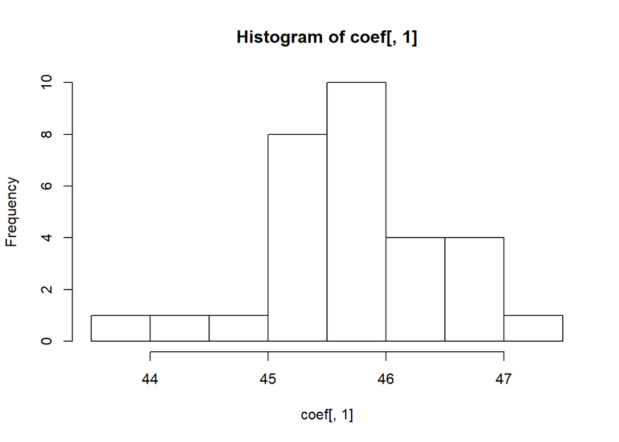

```r
hist(coef[,1])
```

```r
head(Auto)
```

```
##   mpg cylinders displacement horsepower weight acceleration year origin
## 1  18         8          307        130   3504         12.0   70      1
## 2  15         8          350        165   3693         11.5   70      1
## 3  18         8          318        150   3436         11.0   70      1
## 4  16         8          304        150   3433         12.0   70      1
## 5  17         8          302        140   3449         10.5   70      1
## 6  15         8          429        198   4341         10.0   70      1
##                        name
## 1 chevrolet chevelle malibu
## 2         buick skylark 320
## 3        plymouth satellite
## 4             amc rebel sst
## 5               ford torino
## 6          ford galaxie 500
```

```r
train<-Auto
lmfit<-glm(mpg~horsepower+cylinders+ weight, data=train)
summary(lmfit)
```

```
##
## Call:
## glm(formula = mpg ~ horsepower + cylinders + weight, data = train)
##
## Deviance Residuals:
##      Min        1Q    Median        3Q       Max
## -11.5260   -2.7955   -0.3559    2.2567   16.3209
##
## Coefficients:
##               Estimate Std. Error t value Pr(>|t|)
## (Intercept) 45.7368172  0.7959566  57.461  < 2e-16 ***
## horsepower  -0.0427277  0.0116196  -3.677 0.000269 ***
## cylinders   -0.3889745  0.2988302  -1.302 0.193806
## weight      -0.0052723  0.0006424  -8.208 3.37e-15 ***
## ---
## Signif. codes:  0 '***' 0.001 '**' 0.01 '*' 0.05 '.' 0.1 ' ' 1
##
## (Dispersion parameter for gaussian family taken to be 17.947)
##
##     Null deviance: 23819.0  on 391  degrees of freedom
## Residual deviance:  6963.4  on 388  degrees of freedom
## AIC: 2250.3
##
## Number of Fisher Scoring iterations: 2
```

### Klasyfikacja przy pomocy sieci neuronowych

```r
library(neuralnet)
library(nnet)
data(iris)


#one-hot encoder - kodowanie binarne zmiennej
iris$setosa<-  ifelse(iris$Species == "setosa",1,0)
iris$versicolor<-ifelse(iris$Species == "versicolor",1,0)
iris$virginica<-ifelse(iris$Species == "virginica",1,0)

#zamiast tego kodu można użyć z biblioteki nnet:
species_enc<-class.ind(iris$Species)


#normalizujemy atrybuty wejsciowe i dolaczamy trzy binarne kolumny wyjsciowe
iris<-cbind(scale(iris[,1:4]), iris[,6:8])


#przyklad budowy sieci neuronowej  z dwiema ukrytymi warstwami neuronow
f<-as.formula("setosa+versicolor+virginica~Sepal.Width + Sepal.Length + Petal.Width + Petal.Length")
nn<-neuralnet(f, hidden=c(1), data=iris, linear.output=FALSE)
plot(nn)
pred<-compute(nn,iris[,1:4])$net.result
pred_idx<-max.col(pred)
actuals<-iris[,5:7]
actuals_idx<-max.col(actuals)
#dokladnosc modelu procentowa: dla zgodny rekordow mjets TRUE(1), dla błędaów FALSE(0)
accuracy<- mean(actuals_idx==pred_idx)
accuracy
```

```
## [1] 0.9533333333
```

### Bootstrap 0.632 w klasyfikacji

$n$ - liczba obserwacji w próbie danych, losujemy ze zwracaniem $n$ obserwacji.

Prawdopodobieństwo nie wylosowania obserwacji wynosi: $(1- \frac{1}{n})^n \approx e^{-1} \approx 0.368$,

więc oczekiwana liczba unikalnych obserwacji w wulosowanym zbiorze to $0.632n$.

Szacowanie dokładności jest wykonywane mając $b$ próbek bootstrapowych, niech $acc_{i}$ będzie estymatą dokładności klasyfikacji dla ${i}$ - tej próbki bootstrapowej.

$acc_{boot} = \frac{1}{b} \sum_{i=1}^{b}(0.632*acc_{i}+0.368*acc_i)$

Wariancja może być oszacowana na podstawie wariancji estymatora

```r
#przyklad #0.532 bootstrap do szacowania błędu klasyfikacji
acc_table = NULL

for (i in 1:10){
  index <- sample(1:nrow(iris), nrow(iris), replace=TRUE)
  train <- iris[index,]
  test  <- iris[-index,]
  #uczenie sieci , linear,output =FALSE, gdyż zmienne binarne
  nn<-neuralnet(f, hidden=c(1),  data=iris, linear.output = FALSE)
  #wyznaczenie prognoz
  pred<-compute(nn,test[,1:4])$net.result
  pred_idx<-max.col(pred)
  #aktualne
  actuals<-test[,5:7]
  actuals_idx<-max.col(actuals)

  #udzial dobrze zaklasyfikowanych:
  accuracy<- mean(actuals_idx==pred_idx)
  acc_table[i]= accuracy
}

acc_table
```

```
##  [1] 0.9454545455 0.9803921569 0.7169811321 0.6153846154 0.9531250000
##  [6] 0.9615384615 0.9344262295 0.9444444444 0.9444444444 0.9245283019
```

```r
#kalkulacja bledu predykcji


avg_acc<- mean(acc_table)
avg_acc
```

```
## [1] 0.8920719332
```

```r
acc_boot<-mean(0.632*acc_table+0.368*accuracy)
acc_boot
```

```
## [1] 0.9040158769
```